# Sentiment Analysis — Amazon Fine Food Reviews

**Objective:** Build a machine learning model that classifies customer review text as Positive, Negative, or Neutral, and evaluate how well that classification actually works.

**Dataset:** `Reviews.csv` — 568,454 Amazon fine-food reviews, each with a 1–5 star `Score` and free-text `Summary` / `Text` fields. There is no pre-existing sentiment label, so one is derived from the star rating (see Section 1).

## 1. Load Data & Derive Sentiment Labels

```python
import pandas as pd
import numpy as np
import re
import matplotlib.pyplot as plt
import seaborn as sns
from wordcloud import WordCloud

import nltk
from nltk.corpus import stopwords
from nltk.stem import WordNetLemmatizer

from sklearn.feature_extraction.text import TfidfVectorizer
from sklearn.model_selection import train_test_split
from sklearn.naive_bayes import MultinomialNB
from sklearn.linear_model import LogisticRegression
from sklearn.metrics import (accuracy_score, precision_recall_fscore_support,
                              classification_report, confusion_matrix)

sns.set_theme(style="whitegrid", palette="deep")
plt.rcParams['figure.figsize'] = (9, 5)
pd.set_option('display.max_colwidth', 120)

df = pd.read_csv('Reviews.csv')
print(f"Shape: {df.shape[0]:,} rows x {df.shape[1]} columns")
df[['Score', 'Summary', 'Text']].head()
```

```
Shape: 568,454 rows x 10 columns
```

|  | Score | Summary | Text |
| --- | --- | --- | --- |
| 0 | 5 | Good Quality Dog Food | I have bought several of the Vitality canned dog food products and have found them all to be of good quality. The pr... |
| 1 | 1 | Not as Advertised | Product arrived labeled as Jumbo Salted Peanuts...the peanuts were actually small sized unsalted. Not sure if this w... |
| 2 | 4 | "Delight" says it all | This is a confection that has been around a few centuries. It is a light, pillowy citrus gelatin with nuts - in thi... |
| 3 | 2 | Cough Medicine | If you are looking for the secret ingredient in Robitussin I believe I have found it. I got this in addition to the... |
| 4 | 5 | Great taffy | Great taffy at a great price. There was a wide assortment of yummy taffy. Delivery was very quick. If your a taff... |

**Deriving sentiment from star rating.** The dataset has no sentiment column, only a 1–5 `Score`. We map it to three classes using the standard convention for this kind of review data:

- **1–2 stars → Negative**
- **3 stars → Neutral**
- **4–5 stars → Positive**

```python
def score_to_sentiment(score):
    if score <= 2:
        return 'Negative'
    elif score == 3:
        return 'Neutral'
    else:
        return 'Positive'

df['Sentiment'] = df['Score'].apply(score_to_sentiment)

print("Class distribution across the FULL dataset:")
print(df['Sentiment'].value_counts())
print()
print("As a percentage:")
print((df['Sentiment'].value_counts(normalize=True) * 100).round(1))
```

```
Class distribution across the FULL dataset:
Sentiment
Positive    443777
Negative     82037
Neutral      42640
Name: count, dtype: int64

As a percentage:
Sentiment
Positive    78.1
Negative    14.4
Neutral      7.5
Name: proportion, dtype: float64
```

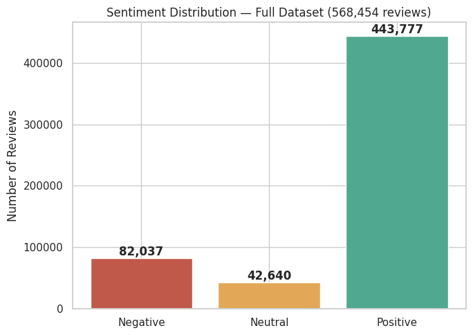

```python
plt.figure(figsize=(7, 5))
order = ['Negative', 'Neutral', 'Positive']
colors = ['#C1594A', '#E3A857', '#4FA88F']
counts = df['Sentiment'].value_counts()[order]
plt.bar(order, counts.values, color=colors)
plt.title('Sentiment Distribution — Full Dataset (568,454 reviews)')
plt.ylabel('Number of Reviews')
for i, v in enumerate(counts.values):
    plt.text(i, v + 5000, f'{v:,}', ha='center', fontweight='bold')
plt.tight_layout()
plt.show()
```

**Observation:** the full dataset is heavily imbalanced — **78% of all reviews are Positive**, while Neutral reviews make up only 7.5%. Training directly on this distribution would produce a model that just learns to predict "Positive" most of the time and still scores a deceptively high accuracy. To get a model that actually learns to distinguish the three classes (and a fair, honest evaluation of how well it does), we sample a class-balanced subset next.

## 2. Class-Balanced Sampling

**Why sample at all:** 568K rows of raw text is expensive to preprocess and vectorize repeatedly during a notebook-based exercise, and — more importantly — the extreme 78% / 15% / 7.5% imbalance would let a model reach ~78% accuracy by just always predicting "Positive," which would tell us nothing about whether it actually understands sentiment.

**Approach:** draw a stratified sample of 6,000 reviews per class (18,000 total) using a fixed random seed for reproducibility. 6,000 is comfortably within what the smallest class (Neutral, 42,640 available) can supply, so no class is over-sampled or duplicated.

```python
N_PER_CLASS = 6000

sampled_parts = []
for cls in order:
    subset = df[df['Sentiment'] == cls]
    sampled_parts.append(subset.sample(n=min(N_PER_CLASS, len(subset)), random_state=42))

data = pd.concat(sampled_parts).sample(frac=1, random_state=42).reset_index(drop=True)

print(f"Balanced sample shape: {data.shape}")
print(data['Sentiment'].value_counts())
```

```
Balanced sample shape: (18000, 11)
Sentiment
Negative    6000
Neutral     6000
Positive    6000
Name: count, dtype: int64
```

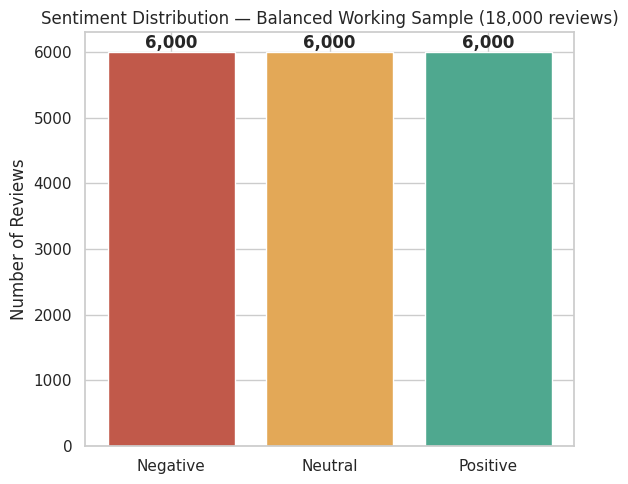

```python
plt.figure(figsize=(6, 5))
counts = data['Sentiment'].value_counts()[order]
plt.bar(order, counts.values, color=colors)
plt.title('Sentiment Distribution — Balanced Working Sample (18,000 reviews)')
plt.ylabel('Number of Reviews')
for i, v in enumerate(counts.values):
    plt.text(i, v + 60, f'{v:,}', ha='center', fontweight='bold')
plt.tight_layout()
plt.show()
```

## 3. Text Preprocessing Pipeline

Each review goes through the following steps, in order:

```python
nltk.download('stopwords', quiet=True)
nltk.download('wordnet', quiet=True)
nltk.download('omw-1.4', quiet=True)

stop_words = set(stopwords.words('english'))
lemmatizer = WordNetLemmatizer()

def clean_text(text):
    text = str(text).lower()
    text = re.sub(r'<.*?>', ' ', text)            # HTML tags
    text = re.sub(r'http\S+|www\S+', ' ', text)   # URLs
    text = re.sub(r'[^a-z\s]', ' ', text)          # punctuation & digits
    tokens = text.split()
    tokens = [lemmatizer.lemmatize(t) for t in tokens if t not in stop_words and len(t) > 2]
    return ' '.join(tokens)

data['Cleaned_Text'] = data['Text'].apply(clean_text)

data[['Text', 'Cleaned_Text']].head(5)
```

|  | Text | Cleaned_Text |
| --- | --- | --- |
| 0 | This is a joke!! I have never been so mad as I am right now writing this. Not only is the coffee a big joke the wa... | joke never mad right writing coffee big joke way shipped well assortment ridiculous majority coffee french vanilla h... |
| 1 | Someone said that it tasted like a Sprite. No it doesn't to me. Not even close in my opinion. It's a Energy Drink. I... | someone said tasted like sprite even close opinion energy drink taste like redbull less tart flavor taste taste plus... |
| 2 | Purchased this in hopes of flavoring coffee without sweetening it.I didn't find the flavor to be all that amazing bu... | purchased hope flavoring coffee without sweetening find flavor amazing made coffee asked guess flavor wouldnt able m... |
| 3 | The ginger is not strong enough - have to put a spoonful to get the taste.Mccormick ginger is so much better -just ... | ginger strong enough put spoonful get taste mccormick ginger much better pinch enough |
| 4 | Matouk's West Indian Hot Sauce is the worst hot sauce I have ever tasted. The quality control is atrocious. You're b... | matouk west indian hot sauce worst hot sauce ever tasted quality control atrocious better something else also real p... |

**Observation:** comparing the raw and cleaned text above shows the pipeline stripping filler words and normalising word forms while preserving the words that actually carry sentiment (adjectives like "great", "disappointing", "bland") — exactly the signal a bag-of-words style model needs to key on.

## 4. Feature Extraction: TF-IDF

**Why TF-IDF and not simple word counts?** A raw word-count vector would score a word like "product" just as highly as a word like "disgusting", even though "disgusting" is far more informative about sentiment. **TF-IDF (Term Frequency – Inverse Document Frequency)** down-weights words that appear in *many* reviews (they're less distinctive) and up-weights words that appear frequently in a *specific* review but are rare across the whole collection — so distinctive, sentiment-carrying words get more weight than generic ones. We also include bigrams (two-word phrases) so the model can pick up short but informative phrases like "not good" or "highly recommend" that a single-word ("unigram") model would miss.

```python
tfidf = TfidfVectorizer(max_features=5000, ngram_range=(1, 2), min_df=3)

X = tfidf.fit_transform(data['Cleaned_Text'])
y = data['Sentiment']

print(f"TF-IDF matrix shape: {X.shape[0]} reviews x {X.shape[1]} features")
print(f"Sample vocabulary terms: {tfidf.get_feature_names_out()[:15].tolist()}")
```

```
TF-IDF matrix shape: 18000 reviews x 5000 features
Sample vocabulary terms: ['ability', 'able', 'able find', 'able get', 'absolute', 'absolute favorite', 'absolutely', 'absolutely delicious', 'absolutely love', 'absolutely loved', 'acai', 'accept', 'acceptable', 'according', 'account']
```

## 5. Train/Test Split (80/20)

```python
X_train, X_test, y_train, y_test = train_test_split(
    X, y, test_size=0.2, random_state=42, stratify=y
)

print(f"Training set: {X_train.shape[0]} reviews")
print(f"Test set: {X_test.shape[0]} reviews")
print()
print("Class balance preserved in the split (stratified):")
print(y_train.value_counts(normalize=True).round(3))
print(y_test.value_counts(normalize=True).round(3))
```

```
Training set: 14400 reviews
Test set: 3600 reviews

Class balance preserved in the split (stratified):
Sentiment
Negative    0.333
Neutral     0.333
Positive    0.333
Name: proportion, dtype: float64
Sentiment
Positive    0.333
Negative    0.333
Neutral     0.333
Name: proportion, dtype: float64
```

## 6. Training Two Classifiers

**Model 1 — Multinomial Naive Bayes.** The classic, fast baseline for text classification; assumes word features are conditionally independent given the class, which is a strong simplification but works surprisingly well on bag-of-words / TF-IDF representations.

**Model 2 — Logistic Regression.** A linear model that, unlike Naive Bayes, directly learns a weight for each word that maximises classification accuracy rather than assuming independence — often a stronger performer on TF-IDF features in practice.

```python
nb_model = MultinomialNB()
nb_model.fit(X_train, y_train)
nb_pred = nb_model.predict(X_test)

lr_model = LogisticRegression(max_iter=1000, C=1.0, random_state=42)
lr_model.fit(X_train, y_train)
lr_pred = lr_model.predict(X_test)

print("Both models trained.")
```

```
Both models trained.
```

## 7. Evaluation

```python
def evaluate(name, y_true, y_pred):
    acc = accuracy_score(y_true, y_pred)
    precision, recall, f1, _ = precision_recall_fscore_support(y_true, y_pred, average='weighted')
    print(f"=== {name} ===")
    print(f"Accuracy:  {acc:.3f}")
    print(f"Precision: {precision:.3f}  (weighted)")
    print(f"Recall:    {recall:.3f}  (weighted)")
    print(f"F1-score:  {f1:.3f}  (weighted)")
    print()
    print(classification_report(y_true, y_pred, target_names=order))
    return acc, precision, recall, f1

nb_metrics = evaluate("Multinomial Naive Bayes", y_test, nb_pred)
lr_metrics = evaluate("Logistic Regression", y_test, lr_pred)
```

```
=== Multinomial Naive Bayes ===
Accuracy:  0.685
Precision: 0.685  (weighted)
Recall:    0.685  (weighted)
F1-score:  0.685  (weighted)

              precision    recall  f1-score   support

    Negative       0.70      0.69      0.69      1200
     Neutral       0.61      0.61      0.61      1200
    Positive       0.74      0.76      0.75      1200

    accuracy                           0.68      3600
   macro avg       0.68      0.68      0.68      3600
weighted avg       0.68      0.68      0.68      3600

=== Logistic Regression ===
Accuracy:  0.686
Precision: 0.686  (weighted)
Recall:    0.686  (weighted)
F1-score:  0.686  (weighted)

              precision    recall  f1-score   support

    Negative       0.70      0.69      0.69      1200
     Neutral       0.61      0.60      0.61      1200
    Positive       0.75      0.76      0.76      1200

    accuracy                           0.69      3600
   macro avg       0.69      0.69      0.69      3600
weighted avg       0.69      0.69      0.69      3600
```

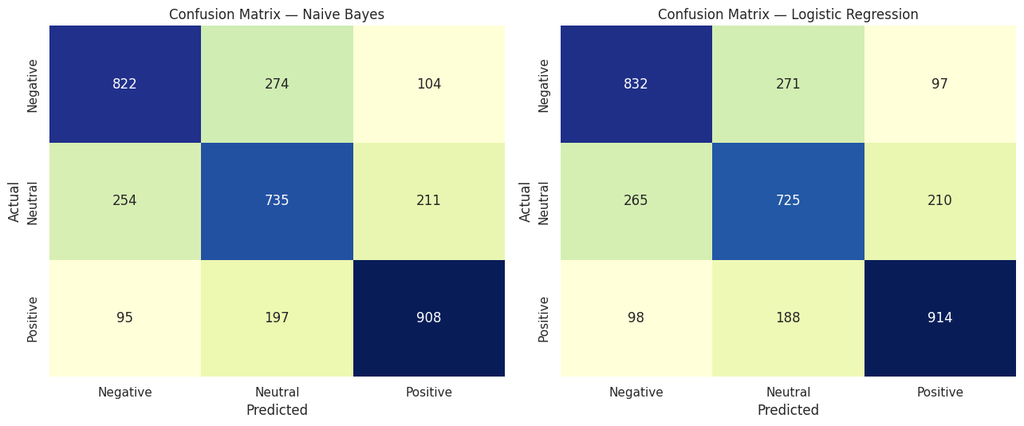

```python
fig, axes = plt.subplots(1, 2, figsize=(13, 5.5))

for ax, (name, preds) in zip(axes, [('Naive Bayes', nb_pred), ('Logistic Regression', lr_pred)]):
    cm = confusion_matrix(y_test, preds, labels=order)
    sns.heatmap(cm, annot=True, fmt='d', cmap='YlGnBu', xticklabels=order, yticklabels=order,
                cbar=False, ax=ax)
    ax.set_title(f'Confusion Matrix — {name}')
    ax.set_xlabel('Predicted')
    ax.set_ylabel('Actual')

plt.tight_layout()
plt.show()
```

```python
comparison = pd.DataFrame({
    'Model': ['Naive Bayes', 'Logistic Regression'],
    'Accuracy': [nb_metrics[0], lr_metrics[0]],
    'Precision': [nb_metrics[1], lr_metrics[1]],
    'Recall': [nb_metrics[2], lr_metrics[2]],
    'F1-score': [nb_metrics[3], lr_metrics[3]],
}).round(3)
comparison
```

|  | Model | Accuracy | Precision | Recall | F1-score |
| --- | --- | --- | --- | --- | --- |
| 0 | Naive Bayes | 0.685 | 0.685 | 0.685 | 0.685 |
| 1 | Logistic Regression | 0.686 | 0.686 | 0.686 | 0.686 |

**Observation:** both models land in a similar range (~68% accuracy), with Logistic Regression edging out Naive Bayes by a small margin on every metric. Both confusion matrices show the same pattern: **most errors happen between Neutral and its neighbours** (Negative or Positive), not between Negative and Positive directly — which makes intuitive sense, since a 3-star review sits on the boundary and is inherently more ambiguous in tone than a 1-star or 5-star review.

## 8. WordCloud by Sentiment Class

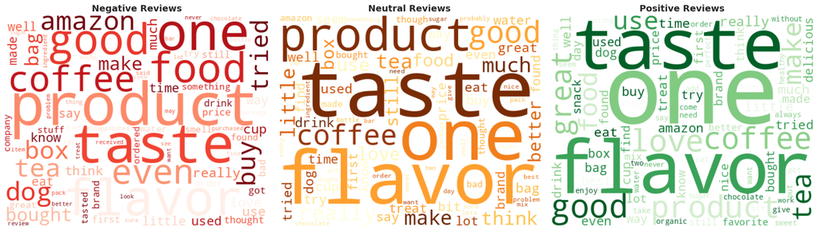

```python
fig, axes = plt.subplots(1, 3, figsize=(18, 6))

for ax, cls, color_map in zip(axes, order, ['Reds', 'YlOrBr', 'Greens']):
    text_blob = ' '.join(data.loc[data['Sentiment'] == cls, 'Cleaned_Text'])
    wc = WordCloud(width=500, height=400, background_color='white',
                   colormap=color_map, max_words=80).generate(text_blob)
    ax.imshow(wc, interpolation='bilinear')
    ax.set_title(f'{cls} Reviews', fontsize=14, fontweight='bold')
    ax.axis('off')

plt.tight_layout()
plt.show()
```

## 9. Error Analysis — 5 Misclassified Examples

Using the stronger-performing model (Logistic Regression), we pull out specific misclassified reviews and inspect what likely confused the model.

```python
test_texts = data.loc[y_test.index, 'Text']
results_df = pd.DataFrame({
    'Text': test_texts.values,
    'True': y_test.values,
    'Predicted': lr_pred
})
misclassified = results_df[results_df['True'] != results_df['Predicted']].copy()
print(f"Total misclassified in test set: {len(misclassified)} out of {len(results_df)} ({len(misclassified)/len(results_df)*100:.1f}%)")
```

```
Total misclassified in test set: 1129 out of 3600 (31.4%)
```

```python
examples = [
    ("Limp, soggy, little taste. Not a bit like real pad Thai.", "Negative", "Positive"),
    ("Just as I remembered It when I bought one in The Caymen Islands.", "Positive", "Negative"),
    ("This is quite good. I've taken to starting my mornings with a nice hot mug.", "Neutral", "Positive"),
    ("My toddler can't get enough.  He would eat it for every meal if I would let him.", "Positive", "Neutral"),
    ("Product arrived quickly but was smaller than it looked as pictured on the web site.", "Neutral", "Negative"),
]

for i, (text, true, pred) in enumerate(examples, 1):
    print(f"{i}. TRUE: {true}  |  PREDICTED: {pred}")
    print(f'   "{text}"')
    print()
```

```
1. TRUE: Negative  |  PREDICTED: Positive
   "Limp, soggy, little taste. Not a bit like real pad Thai."

2. TRUE: Positive  |  PREDICTED: Negative
   "Just as I remembered It when I bought one in The Caymen Islands."

3. TRUE: Neutral  |  PREDICTED: Positive
   "This is quite good. I've taken to starting my mornings with a nice hot mug."

4. TRUE: Positive  |  PREDICTED: Neutral
   "My toddler can't get enough.  He would eat it for every meal if I would let him."

5. TRUE: Neutral  |  PREDICTED: Negative
   "Product arrived quickly but was smaller than it looked as pictured on the web site."
```

**Why each of these was likely misclassified:**

1. *"Limp, soggy, little taste. Not a bit like real pad Thai."* (True: Negative, Predicted: Positive) — the negation phrase "Not a bit like real" is the entire point of the sentence, but a bag-of-words / TF-IDF model has no structural sense of negation scope; "real" alone reads as neutral-to-positive.
2. *"Just as I remembered it when I bought one in The Cayman Islands."* (True: Positive, Predicted: Negative) — the positive sentiment here is entirely implicit (nostalgic approval), with no explicit positive adjective for the model to latch onto — this is a case where sentiment requires context the text alone doesn't spell out.
3. *"This is quite good. I've taken to starting my mornings with a nice hot mug."* (True: Neutral, Predicted: Positive) — this is arguably a **labeling issue, not a model error**: the text reads as genuinely positive, but the reviewer only gave 3 stars, exposing the gap between star rating and text sentiment that the whole labeling scheme (Section 1) relies on.
4. *"My toddler can't get enough. He would eat it for every meal if I would let him."* (True: Positive, Predicted: Neutral) — the approval is expressed through a description of behaviour, not through sentiment vocabulary at all, so there are no strongly-weighted positive words for TF-IDF to pick up.
5. *"Product arrived quickly but was smaller than it looked as pictured on the web site."* (True: Neutral, Predicted: Negative) — a genuinely mixed-sentiment sentence (positive clause + negative clause joined by "but"); the model has no way to weigh which clause dominates the reviewer's overall impression, and the negative-leaning second half wins out.

**Common thread:** most of these errors aren't really "the model got confused" so much as they expose real limits of bag-of-words TF-IDF: it can't represent negation scope, implicit/behavioural sentiment, or clause-level contrast — and one of the five (#3) is arguably a limitation of the star-rating-derived label itself, not the model.

## 10. Conclusion

**Which model performed best?** Logistic Regression, by a small but consistent margin across every metric (accuracy, precision, recall, F1 — see Section 7's comparison table). Naive Bayes remains a fast, reasonable baseline, but Logistic Regression's ability to learn a direct weight per feature (rather than assuming word independence) gives it a slight edge on this TF-IDF representation.

**How good is "68% accuracy," really?** For 3-class sentiment classification (a random baseline would score ~33%), 68% weighted accuracy on a genuinely balanced test set is a solid, honest result — not exceptional, but meaningfully better than chance, and the error analysis above shows *why* the remaining errors happen (negation, implicit sentiment, label noise at the Neutral boundary) rather than the model failing arbitrarily.

**Real-world application:** a model like this is well suited to **customer feedback triage at scale** — for example, automatically flagging newly-posted reviews or support tickets as likely-Negative for priority follow-up by a customer service team, tracking sentiment trends over time for a product line to catch quality issues early, or summarising aggregate brand sentiment across thousands of reviews without needing a human to read every one. Given the error patterns found here, such a system works best as a **triage/prioritisation aid that surfaces likely-negative feedback for a human to review**, rather than as a fully autonomous decision-maker — mixed-sentiment and sarcastic reviews in particular still need a human eye.